# ggplot2 : 6. Axes

```r
# install.packages(c('ggplot2’, 'gcookbook’), dependencies = TRUE)
library(ggplot2)
library(gcookbook)
```

## Swapping X- and Y-Axes

```r
ggplot(PlantGrowth, aes(x = group, y = weight)) + geom_boxplot()
```

[output not shown]

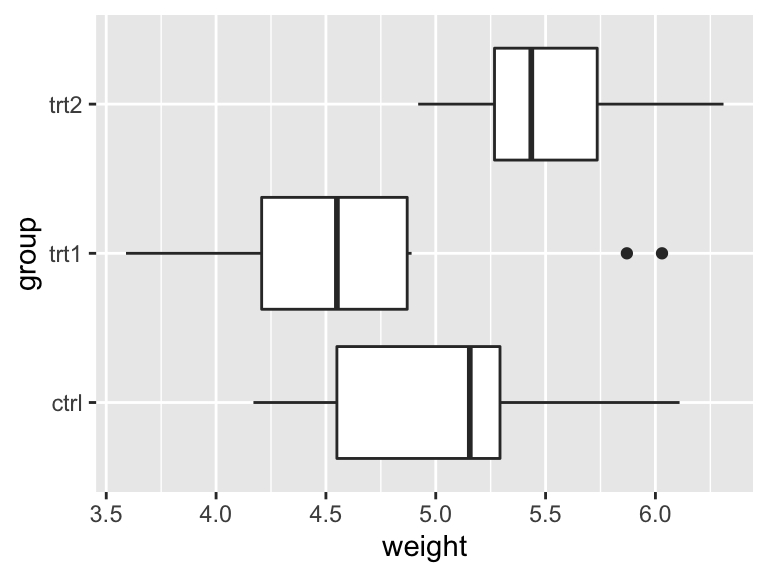

```r
ggplot(PlantGrowth, aes(x = group, y = weight)) + geom_boxplot() + coord_flip()
```

- `coord_flip()` : 그래프의 두 축을 바꿈. 이 경우 aes 함수에서 x축 및 y축에 놓일 변수명이 두 축이 바꾸기 전에 해당함을 주의 할 것.

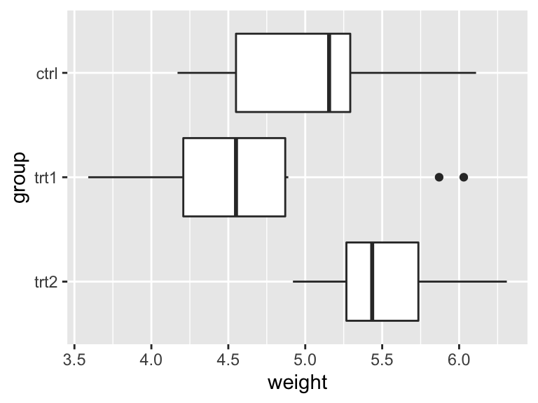

```r
ggplot(PlantGrowth, aes(x = group, y = weight)) + geom_boxplot() + coord_flip() +
  scale_x_discrete(limits = rev(levels(PlantGrowth$group)))
```

- `scale_x_discrete()` : x축의 변수가 discrete(factor변수) 인 경우, x축의 tick label 등에 대한 그래픽 옵션 수행.
- `coord_flip()`을 통해 두 축이 뒤바뀐 경우, `scale_x_discrete()`은 y축에 적용됨.

## Setting the Range of a Continuous Axis

```r
p <- ggplot(PlantGrowth, aes(x = group, y = weight)) + geom_boxplot()
p
```

[output not shown]

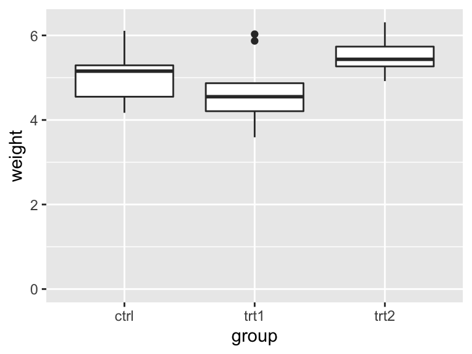

```r
p + ylim(0, max(PlantGrowth$weight))
```

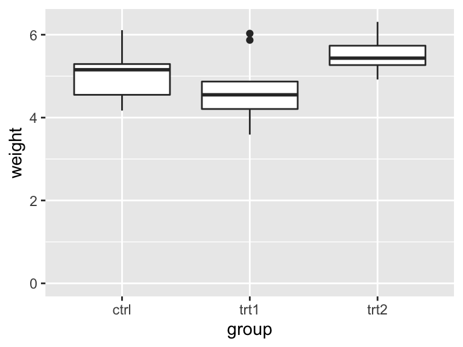

```r
# "ylim()" is shorthand for setting the limits with "scale_y_continuous()"
p + scale_y_continuous(limits = c(0, max(PlantGrowth$weight)))
```

- `scale_y_continuous()` : 변수가 continuous(numeric 변수) 인 경우, y축의 범위 및 tick label 등에 대한 그래픽 옵션을 지정. 축의 범위만을 지정하는 경우, `ylim()`이란 short-hand 함수를 이용하면 편리.

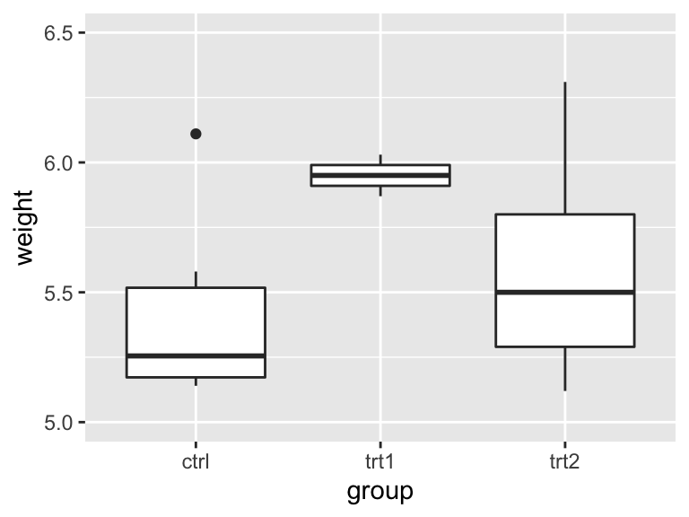

```r
p <- ggplot(PlantGrowth, aes(x = group, y = weight)) + geom_boxplot()
p + scale_y_continuous(limits = c(5, 6.5)) # redraw boxplots within the limit
```

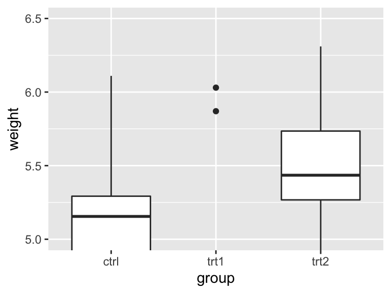

```r
p + coord_cartesian(ylim = c(5, 6.5))  # magnify the limit region
```

- `scale_y_continuous(limits = c(5, 6.5))` 로 y축의 그래픽 영역을 지정하는 경우, 해당 범위를 만족하는 자료만 이용.
- `coord_cartesian(ylim = c(5, 6.5))` 함수 또한 y축의 범위를 한정하지만, 이 경우에는 범위에 벗어난 자료를 포함한 모든 자료가 그래픽에 이용되고 결과 그림에서는 해당 영역만 display 됨. 결과적으로 해당 영역이 확대되어 나타남.

## Reversing a Continuous Axis

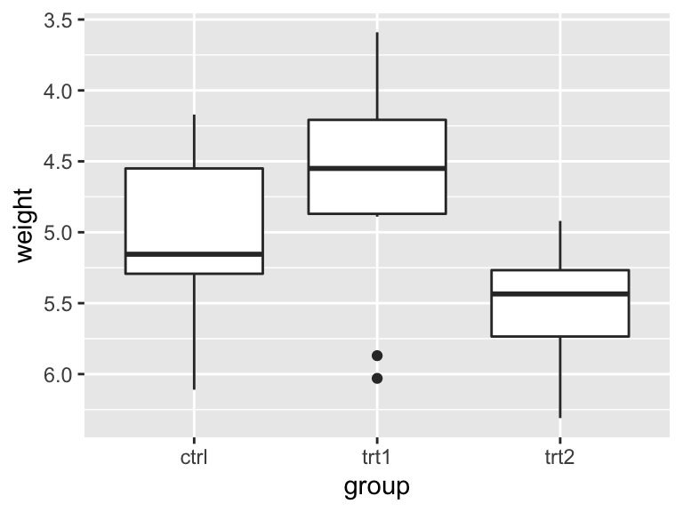

```r
p <- ggplot(PlantGrowth, aes(x = group, y = weight)) + geom_boxplot()
p + scale_y_reverse()
```

- `scale_y_reverse()` : y축의 자료를 역순으로 그래픽에 출력함.

## Changing the Order of Items on a Categorical Axis

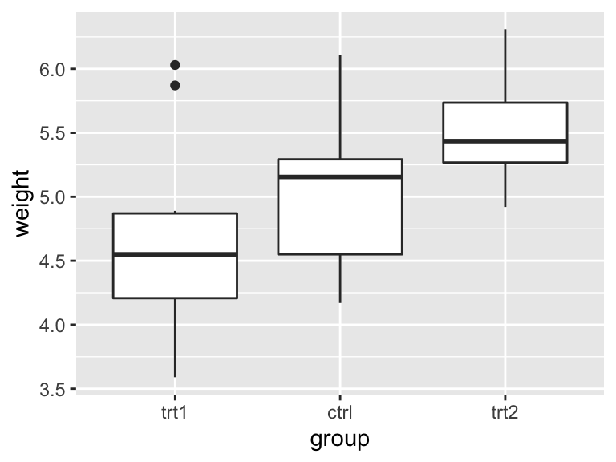

```r
p <- ggplot(PlantGrowth, aes(x = group, y = weight)) + geom_boxplot()
p + scale_x_discrete(limits = c('trt1', 'ctrl', 'trt2'))
```

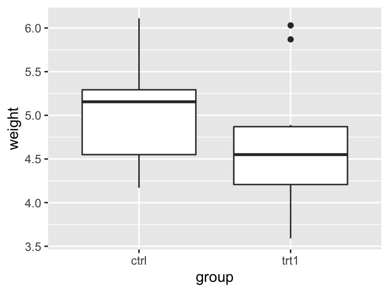

```r
p + scale_x_discrete(limits = c('ctrl', 'trt1'))
```

- `scale_x_discrete(limits = )` : 범주형 자료의 변수값의 순서를 바꾸거나 레벨의 일부만을 출력.

## Setting the Positions of Tick Marks

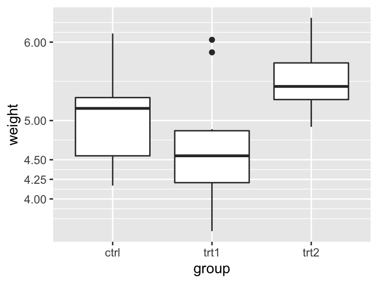

```r
p <- ggplot(PlantGrowth, aes(x = group, y = weight)) + geom_boxplot()
p + scale_y_continuous(breaks = c(4, 4.25, 4.5, 5, 6, 8))
```

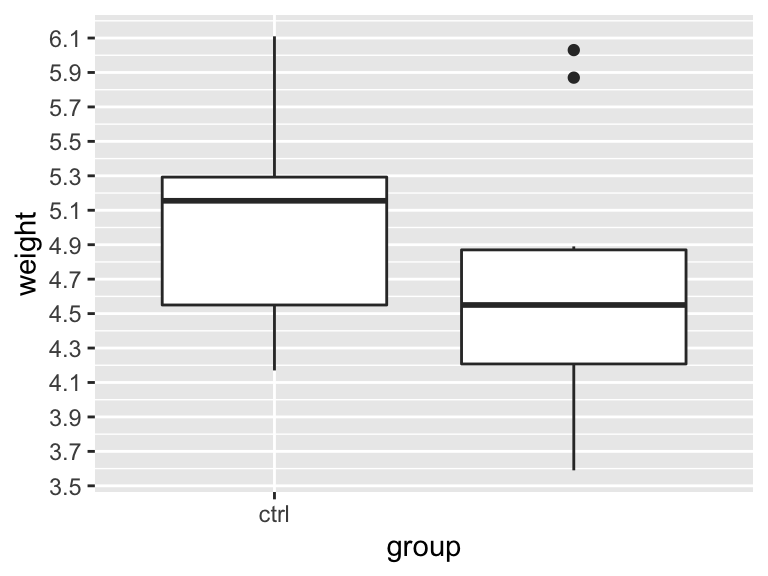

```r
mytick <- seq(3.5, 7, by = 0.2)
p + scale_y_continuous(breaks = mytick) +
  scale_x_discrete(limits = c('ctrl', 'trt1'), breaks = 'ctrl')
```

- `scale_x_discrete()` : 범주형 자료의 변수값의 tick marks를 조절.
- `scale_y_continuous()` : 연속형 자료의 변수값의 tick marks를 조절.

## Removing Tick Marks and Labels

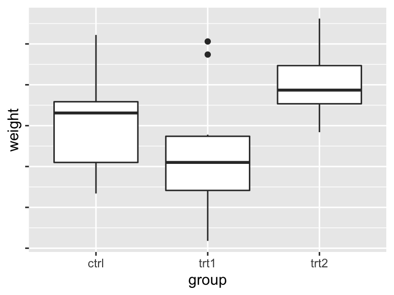

```r
p <- ggplot(PlantGrowth, aes(x = group, y = weight)) + geom_boxplot()
p + theme(axis.text.y = element_blank())
```

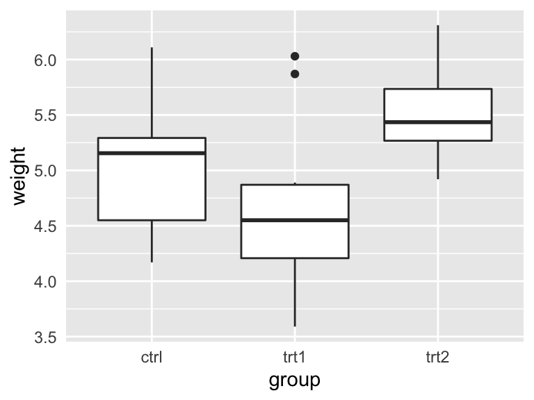

```r
p + theme(axis.ticks = element_blank())
```

- `theme(axis.text.y = element_blank())` : `theme()` 함수를 이용하여 y축의 tick label에 대한 옵션을 `element_blank()`로 두어 표시되지 않게 함.
- `theme(axis.ticks = element_blank())` : `theme()` 함수를 이용하여 모든 축의 tick mark에 대한 옵션을 `element_blank()`로 두어 표시 되지 않게 함.

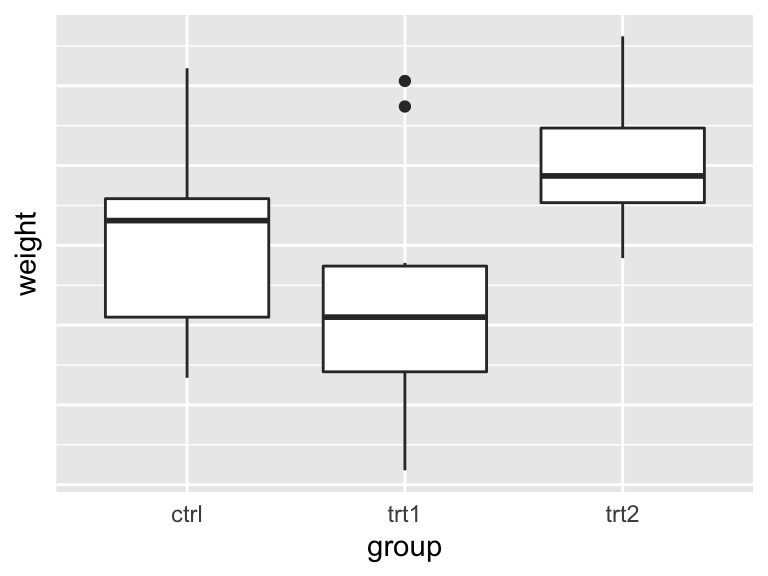

```r
p <- ggplot(PlantGrowth, aes(x = group, y = weight)) + geom_boxplot()
p + theme(axis.ticks = element_blank(), axis.text.y = element_blank())
```

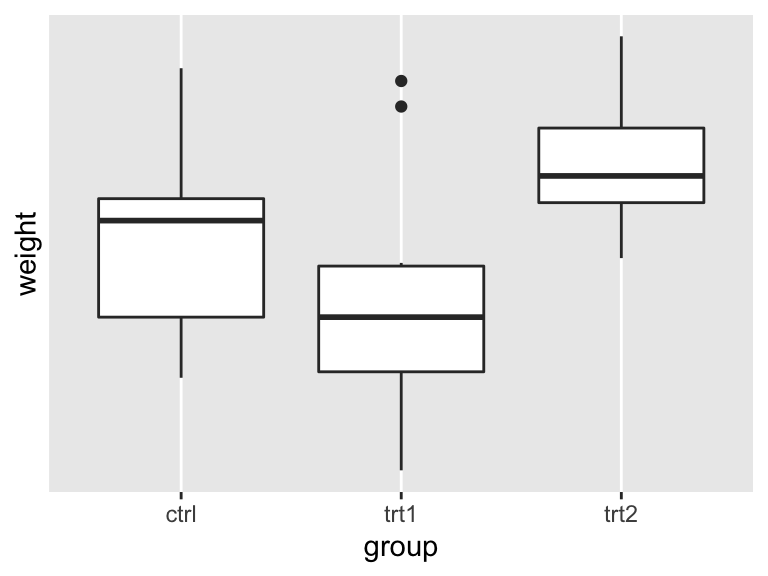

```r
p + scale_y_continuous(breaks = NULL) # remove grids on y
```

- `theme(axis.ticks = element_blank(), axis.text.y = element_blank())` : `theme()` 함수를 이용하여 y축의 tick label에 대한 옵션을 `element_blank()`로 두어 표시되지 않게 하고 모든 축의 tick mark를 사라지게 함.
- `scale_y_continuous(breaks = NULL)` : `breaks = NULL` 로 두어 y축(연속형변수)의 grid를 사라지게 함.

## Changing the Text of Tick Labels

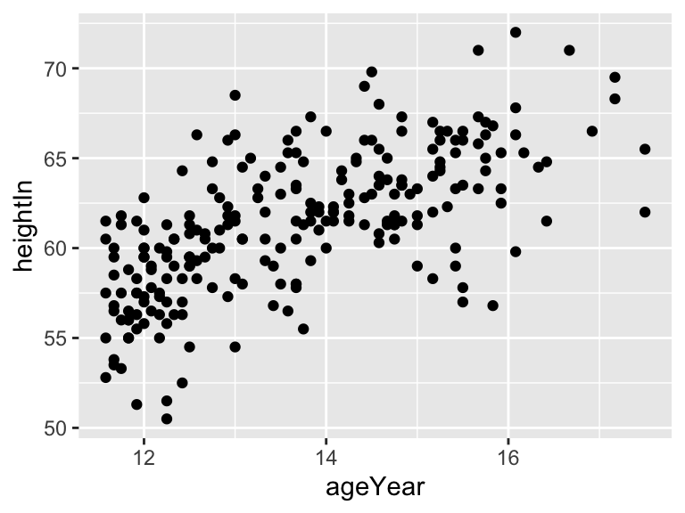

```r
hwp <- ggplot(heightweight, aes(x = ageYear, y = heightIn)) + geom_point()
hwp
```

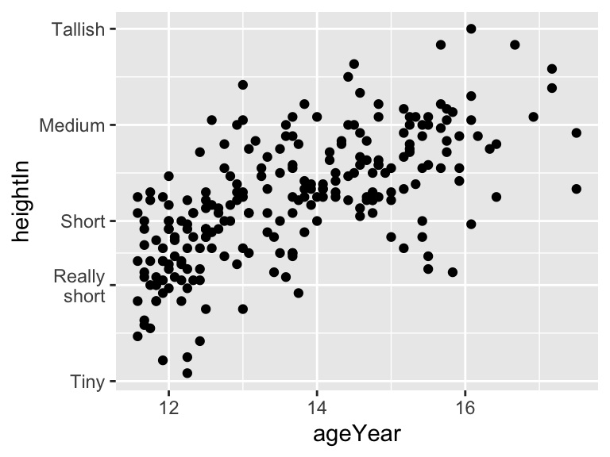

```r
hwp + scale_y_continuous(breaks = c(50, 56, 60, 66, 72),
                         labels = c( 'Tiny', 'Really\nshort', 'Short', 'Medium', 'Tallish'))
```

- `breaks = c(50, 56, 60, 66, 72)` 으로 tick 위치를 지정하고 해당 tick에 `labels = c(‘Tiny’, ‘Really\nshort’, ‘Short’, ‘Medium’, ‘Tallish’)`을 이용하여 label문을 변경함.
- 텍스트에 escape문자 삽입하여 한줄 내려 출력.

```r
footinch_formatter <- function (x) {
  foot <- floor(x / 12)
  inch <- x %% 12
  return( paste(foot, "'", inch, "\"", sep = ''))
}
footinch_formatter(56:64)
```

```
## [1] "4'8\""  "4'9\""  "4'10\"" "4'11\"" "5'0\""  "5'1\""  "5'2\""  "5'3\""
## [9] "5'4\""
```

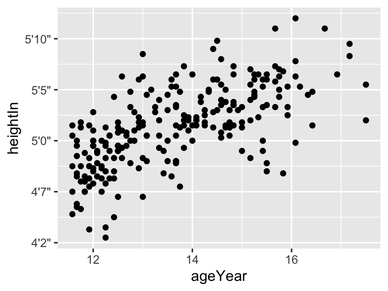

```r
hwp + scale_y_continuous(labels = footinch_formatter)
```

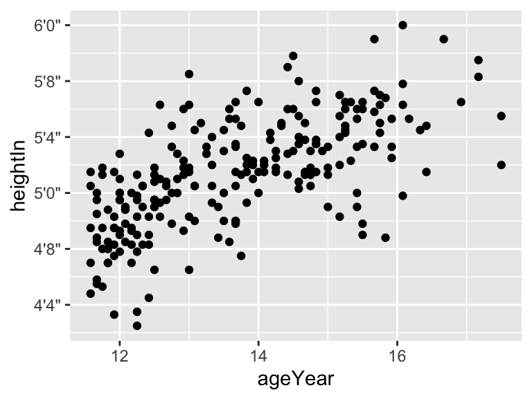

```r
hwp + scale_y_continuous(breaks = seq(48, 72, by = 4), labels = footinch_formatter)
```

- `footinch_formatter` : 인치 단위를 피트/인치로 변환하는 함수.
- `scale_y_continous(labels = footinch_formatter)`를 적용함으로써 y축의 scale을 footinch_formatter의 형식으로 표현 가능.
- `floor()` : 함수 인자의 값보다 작거나 같은 정수 중 최대값을 출력.
- `%%` : 나눗셈의 나머지를 출력.

```r
timeHMS_formatter <- function (x) {
  h <- floor(x / 60)  # hour
  m <- floor(x %% 60) # minute
  s <- round(60 * (x %% 1)) # Round to nearest second
  lab <- sprintf("%02d:%02d:%02d", h, m, s) # Format the strings as HH:MM:SS
  lab <- gsub("^00:", "", lab)  # Remove leading 00: if present
  lab <- gsub("^0", "", lab)  # Remove leading 0 if present
  return (lab)
}
timeHMS_formatter( c(.33, 50, 51, 51.25, 60, 60.1, 130.23, 1234))
```

```
## [1] "0:20"     "50:00"    "51:00"    "51:15"    "1:00:00"  "1:00:06"  "2:10:14"
## [8] "20:34:00"
```

- `timeHMS_formatter` : 분(minute) 단위로 기록된 시간을 시/분/초(HH/MM/SS) 단위로 변환.

## Changing the Appearance of Tick Labels

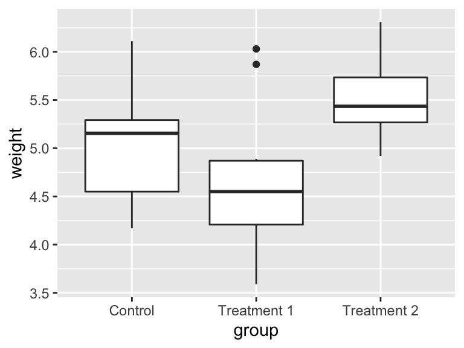

```r
bp <- ggplot(PlantGrowth, aes(x = group, y = weight)) + geom_boxplot() +
  scale_x_discrete(breaks = c('ctrl', 'trt1', 'trt2'),
  labels = c('Control', 'Treatment 1', 'Treatment 2'))
bp
```

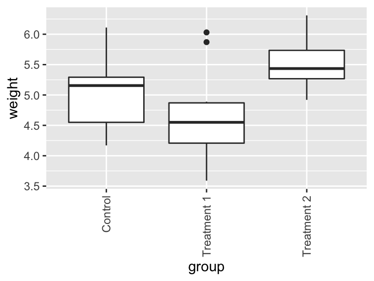

```r
bp + theme(axis.text.x = element_text(angle = 90, hjust = 1, vjust = 0.5))
```

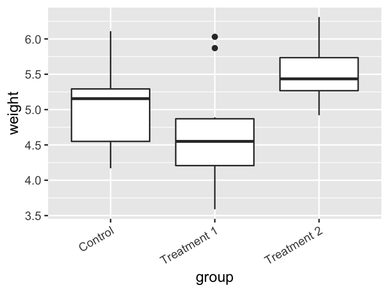

```r
bp + theme(axis.text.x = element_text(angle = 30, hjust = 1, vjust = 1))
```

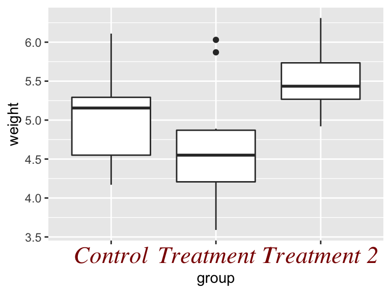

```r
bp + theme(axis.text.x = element_text(family = 'Times', face = 'italic', color = 'darkred', size=rel(2)))
```

```r
library(extrafont)
font_import()   # take more than 5 minutes
```

```
## Importing fonts may take a few minutes, depending on the number of fonts and the speed of the system.
## Continue? [y/n]
```

```
## Exiting.
```

```r
fonts()
```

[output not shown]

[output cut: 55 more lines]

- 함수 `theme()` 내부에 `axis.text.x = element_text()`를 이용하여 tick label의 모양을 변경.
- `angle` : 텍스트의 각도 조절.
- `hjust`, `vjust` : 텍스트의 위치 미세조정.
- `family` : 텍스트의 폰트 모양 조절.
- `face` : 텍스트의 typeset을 조절.
- 다양한 글씨체를 얻기 위해, 패키지 extrafont를 설치할 것.

## Changing the Text of Axis Labels

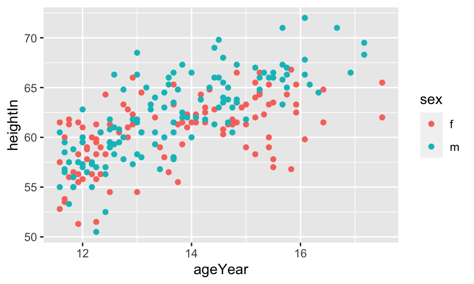

```r
hwp <- ggplot(heightweight, aes(x = ageYear, y = heightIn, color = sex)) + geom_point()
hwp
```

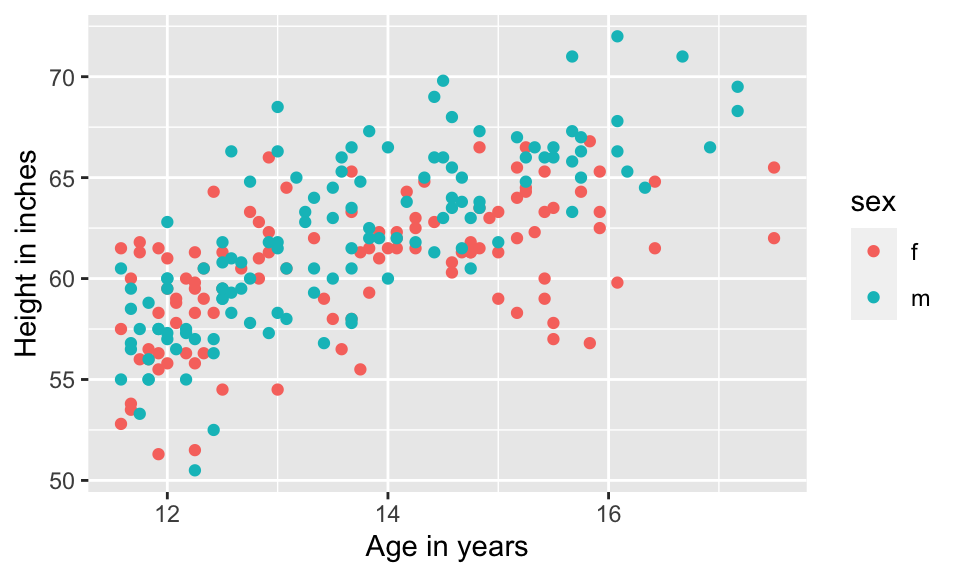

```r
# set the axis labels
hwp + xlab('Age in years') + ylab('Height in inches')
```

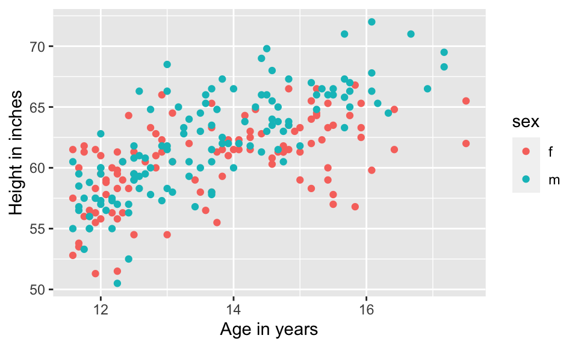

```r
hwp + labs(x = 'Age in years', y = 'Height in inches')
```

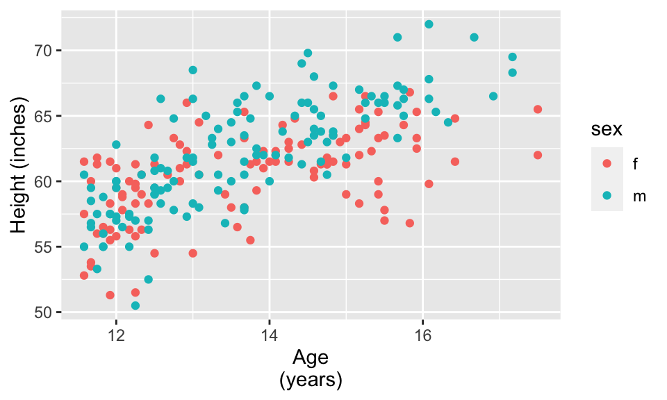

```r
hwp + scale_y_continuous(name = 'Height (inches)') + scale_x_continuous(name = 'Age\n(years)')
```

- `xlab()`, `ylab()`, `labs()`, `scale_x_continuous()`, `scale_y_continuous()` 등을 이용하여 각 축의 label을 바꿀 수 있음.

## Removing Axis Labels

```r
p <- ggplot(PlantGrowth, aes(x = group, y = weight)) + geom_boxplot()
p
```

[output not shown]

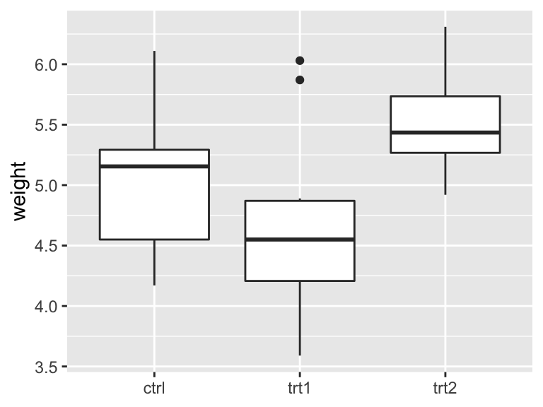

```r
p + theme(axis.title.x = element_blank())
```

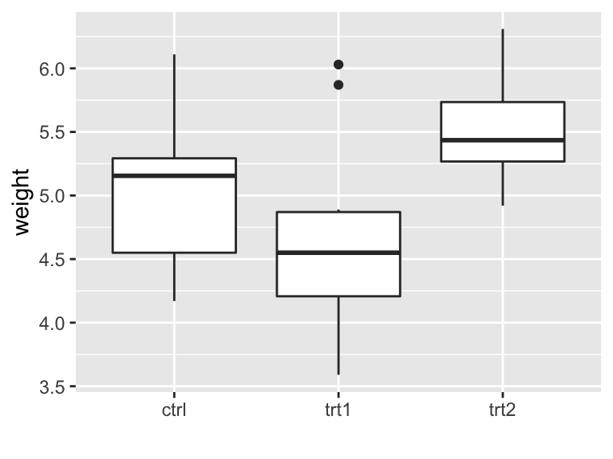

```r
p + xlab('')
```

- `xlab(‘’)`, `theme(axis.title.x = element_blank())` 등을 이용하여 x축의 label을 삭제할 수 있음.
- `xlab(‘’)`은 x축의 label을 공백으로 처리하므로 이에 대한 여백이 남아 있게 되는 반면, `theme(axis.title.x = element_blank())`는 그래프에 x축의 label을 원천적으로 이용하지 않으므로 label을 위한 여백이 남지 않음.

## Changing the Appearance of Axis Labels

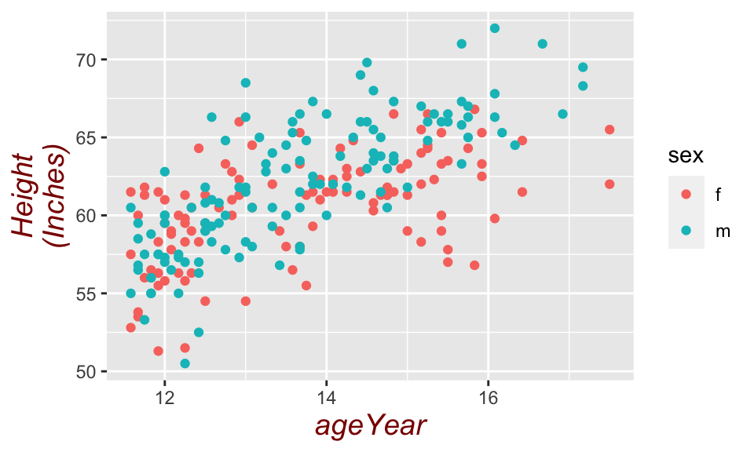

```r
hwp <- ggplot(heightweight, aes(x = ageYear, y = heightIn, color = sex)) +
    geom_point()
hwp + theme(axis.title.x = element_text(face = 'italic', color ='darkred', size = 14)) +
  theme(axis.title.y = element_text(face = 'italic', angle = 90, color = 'darkred', size = 14)) +
  ylab('Height\n(Inches)')
```

- `element_text()` 함수를 이용하여 axis label의 모양을 다양하게 바꿀수 있음.